# Credit Card Fraud Detection

This is the one of the Kaggle competition problem. And below details about dataset are available at [kaggle](https://www.kaggle.com/mlg-ulb/creditcardfraud)

**Context** It is important that credit card companies are able to recognize fraudulent credit card transactions so that customers are not charged for items that they did not purchase.

**Content** The datasets contains transactions made by credit cards in September 2013 by european cardholders. This dataset presents transactions that occurred in two days, where we have 492 frauds out of 284,807 transactions. The dataset is highly unbalanced, the positive class (frauds) account for 0.172% of all transactions.

It contains only numerical input variables which are the result of a PCA transformation. Unfortunately, due to confidentiality issues, we cannot provide the original features and more background information about the data. Features V1, V2, ... V28 are the principal components obtained with PCA, the only features which have not been transformed with PCA are 'Time' and 'Amount'. Feature 'Time' contains the seconds elapsed between each transaction and the first transaction in the dataset. The feature 'Amount' is the transaction Amount, this feature can be used for example-dependant cost-senstive learning. Feature 'Class' is the response variable and it takes value 1 in case of fraud and 0 otherwise

**Business Problem** : Find out which transaction is fraud or Not

To solve the problem , we can divide it into below parts.

```python
# Import the libraries
import pandas as pd
import numpy as np
import matplotlib.pyplot as plt
import seaborn as sns
import scipy as sc
import warnings
import heapq

#Import Sklearn libary
from sklearn.linear_model import LogisticRegression
from sklearn.model_selection import train_test_split
from sklearn.svm import SVC
from sklearn.naive_bayes import GaussianNB
from sklearn.tree import DecisionTreeClassifier
from sklearn.neighbors import KNeighborsClassifier
from sklearn.model_selection import KFold
from sklearn.model_selection import cross_val_score
from sklearn.preprocessing import StandardScaler,LabelEncoder
from sklearn.pipeline import Pipeline
from sklearn.model_selection import GridSearchCV
from sklearn.ensemble import ExtraTreesClassifier
#from sklearn.model_selection import GridSearchCV
from sklearn.ensemble import AdaBoostClassifier
from sklearn.ensemble import GradientBoostingClassifier
from sklearn.ensemble import RandomForestClassifier
from sklearn.metrics import accuracy_score
from sklearn.metrics import confusion_matrix
from sklearn.metrics import classification_report
from sklearn.metrics import roc_curve, auc,roc_auc_score
%matplotlib inline

#import for imbalance dataset
from imblearn.over_sampling import SMOTE,ADASYN
```

```python
warnings.filterwarnings("ignore")
```

## Exploratory data Analysis

Lets get started with some basic analysis over dataset to understand it.

```python
#import the dataset
dt_train_origin=pd.read_csv("creditcard.csv",sep=',')
dt_train=dt_train_origin.copy()
```

```python
#First few rows
dt_train.head()
```

|  | Time | V1 | V2 | V3 | V4 | V5 | V6 | V7 | V8 | V9 | ... | V21 | V22 | V23 | V24 | V25 | V26 | V27 | V28 | Amount | Class |
| --- | --- | --- | --- | --- | --- | --- | --- | --- | --- | --- | --- | --- | --- | --- | --- | --- | --- | --- | --- | --- | --- |
| 0 | 0.0 | -1.359807 | -0.072781 | 2.536347 | 1.378155 | -0.338321 | 0.462388 | 0.239599 | 0.098698 | 0.363787 | ... | -0.018307 | 0.277838 | -0.110474 | 0.066928 | 0.128539 | -0.189115 | 0.133558 | -0.021053 | 149.62 | 0 |
| 1 | 0.0 | 1.191857 | 0.266151 | 0.166480 | 0.448154 | 0.060018 | -0.082361 | -0.078803 | 0.085102 | -0.255425 | ... | -0.225775 | -0.638672 | 0.101288 | -0.339846 | 0.167170 | 0.125895 | -0.008983 | 0.014724 | 2.69 | 0 |
| 2 | 1.0 | -1.358354 | -1.340163 | 1.773209 | 0.379780 | -0.503198 | 1.800499 | 0.791461 | 0.247676 | -1.514654 | ... | 0.247998 | 0.771679 | 0.909412 | -0.689281 | -0.327642 | -0.139097 | -0.055353 | -0.059752 | 378.66 | 0 |
| 3 | 1.0 | -0.966272 | -0.185226 | 1.792993 | -0.863291 | -0.010309 | 1.247203 | 0.237609 | 0.377436 | -1.387024 | ... | -0.108300 | 0.005274 | -0.190321 | -1.175575 | 0.647376 | -0.221929 | 0.062723 | 0.061458 | 123.50 | 0 |
| 4 | 2.0 | -1.158233 | 0.877737 | 1.548718 | 0.403034 | -0.407193 | 0.095921 | 0.592941 | -0.270533 | 0.817739 | ... | -0.009431 | 0.798278 | -0.137458 | 0.141267 | -0.206010 | 0.502292 | 0.219422 | 0.215153 | 69.99 | 0 |

5 rows × 31 columns

```python
# check missing value
dt_train.isnull().sum().sum()
```

```
0
```

```python
# check missing value
dt_train.isnull().any().any()
```

```
False
```

```python
#description of datset
dt_train.describe(include='all')
#rint(dt_train.groupby('Class').size())
```

|  | Time | V1 | V2 | V3 | V4 | V5 | V6 | V7 | V8 | V9 | ... | V21 | V22 | V23 | V24 | V25 | V26 | V27 | V28 | Amount | Class |
| --- | --- | --- | --- | --- | --- | --- | --- | --- | --- | --- | --- | --- | --- | --- | --- | --- | --- | --- | --- | --- | --- |
| count | 284807.000000 | 2.848070e+05 | 2.848070e+05 | 2.848070e+05 | 2.848070e+05 | 2.848070e+05 | 2.848070e+05 | 2.848070e+05 | 2.848070e+05 | 2.848070e+05 | ... | 2.848070e+05 | 2.848070e+05 | 2.848070e+05 | 2.848070e+05 | 2.848070e+05 | 2.848070e+05 | 2.848070e+05 | 2.848070e+05 | 284807.000000 | 284807.000000 |
| mean | 94813.859575 | 3.919560e-15 | 5.688174e-16 | -8.769071e-15 | 2.782312e-15 | -1.552563e-15 | 2.010663e-15 | -1.694249e-15 | -1.927028e-16 | -3.137024e-15 | ... | 1.537294e-16 | 7.959909e-16 | 5.367590e-16 | 4.458112e-15 | 1.453003e-15 | 1.699104e-15 | -3.660161e-16 | -1.206049e-16 | 88.349619 | 0.001727 |
| std | 47488.145955 | 1.958696e+00 | 1.651309e+00 | 1.516255e+00 | 1.415869e+00 | 1.380247e+00 | 1.332271e+00 | 1.237094e+00 | 1.194353e+00 | 1.098632e+00 | ... | 7.345240e-01 | 7.257016e-01 | 6.244603e-01 | 6.056471e-01 | 5.212781e-01 | 4.822270e-01 | 4.036325e-01 | 3.300833e-01 | 250.120109 | 0.041527 |
| min | 0.000000 | -5.640751e+01 | -7.271573e+01 | -4.832559e+01 | -5.683171e+00 | -1.137433e+02 | -2.616051e+01 | -4.355724e+01 | -7.321672e+01 | -1.343407e+01 | ... | -3.483038e+01 | -1.093314e+01 | -4.480774e+01 | -2.836627e+00 | -1.029540e+01 | -2.604551e+00 | -2.256568e+01 | -1.543008e+01 | 0.000000 | 0.000000 |
| 25% | 54201.500000 | -9.203734e-01 | -5.985499e-01 | -8.903648e-01 | -8.486401e-01 | -6.915971e-01 | -7.682956e-01 | -5.540759e-01 | -2.086297e-01 | -6.430976e-01 | ... | -2.283949e-01 | -5.423504e-01 | -1.618463e-01 | -3.545861e-01 | -3.171451e-01 | -3.269839e-01 | -7.083953e-02 | -5.295979e-02 | 5.600000 | 0.000000 |
| 50% | 84692.000000 | 1.810880e-02 | 6.548556e-02 | 1.798463e-01 | -1.984653e-02 | -5.433583e-02 | -2.741871e-01 | 4.010308e-02 | 2.235804e-02 | -5.142873e-02 | ... | -2.945017e-02 | 6.781943e-03 | -1.119293e-02 | 4.097606e-02 | 1.659350e-02 | -5.213911e-02 | 1.342146e-03 | 1.124383e-02 | 22.000000 | 0.000000 |
| 75% | 139320.500000 | 1.315642e+00 | 8.037239e-01 | 1.027196e+00 | 7.433413e-01 | 6.119264e-01 | 3.985649e-01 | 5.704361e-01 | 3.273459e-01 | 5.971390e-01 | ... | 1.863772e-01 | 5.285536e-01 | 1.476421e-01 | 4.395266e-01 | 3.507156e-01 | 2.409522e-01 | 9.104512e-02 | 7.827995e-02 | 77.165000 | 0.000000 |
| max | 172792.000000 | 2.454930e+00 | 2.205773e+01 | 9.382558e+00 | 1.687534e+01 | 3.480167e+01 | 7.330163e+01 | 1.205895e+02 | 2.000721e+01 | 1.559499e+01 | ... | 2.720284e+01 | 1.050309e+01 | 2.252841e+01 | 4.584549e+00 | 7.519589e+00 | 3.517346e+00 | 3.161220e+01 | 3.384781e+01 | 25691.160000 | 1.000000 |

8 rows × 31 columns

```python
#info of dataset
dt_train.info()
```

```
<class 'pandas.core.frame.DataFrame'>
RangeIndex: 284807 entries, 0 to 284806
Data columns (total 31 columns):
Time      284807 non-null float64
V1        284807 non-null float64
V2        284807 non-null float64
V3        284807 non-null float64
V4        284807 non-null float64
V5        284807 non-null float64
V6        284807 non-null float64
V7        284807 non-null float64
V8        284807 non-null float64
V9        284807 non-null float64
V10       284807 non-null float64
V11       284807 non-null float64
V12       284807 non-null float64
V13       284807 non-null float64
V14       284807 non-null float64
V15       284807 non-null float64
V16       284807 non-null float64
V17       284807 non-null float64
V18       284807 non-null float64
V19       284807 non-null float64
V20       284807 non-null float64
V21       284807 non-null float64
V22       284807 non-null float64
V23       284807 non-null float64
V24       284807 non-null float64
V25       284807 non-null float64
V26       284807 non-null float64
V27       284807 non-null float64
V28       284807 non-null float64
Amount    284807 non-null float64
Class     284807 non-null int64
dtypes: float64(30), int64(1)
memory usage: 67.4 MB
```

```python
#shape of Dataset
dt_train.shape
```

```
(284807, 31)
```

```
0    284315
1       492
Name: Class, dtype: int64
```

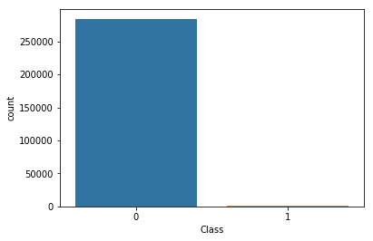

```python
# Understand the target
%matplotlib inline
print(dt_train['Class'].value_counts())
sns.countplot(dt_train['Class'])
plt.show()
```

## Multivariate analysis

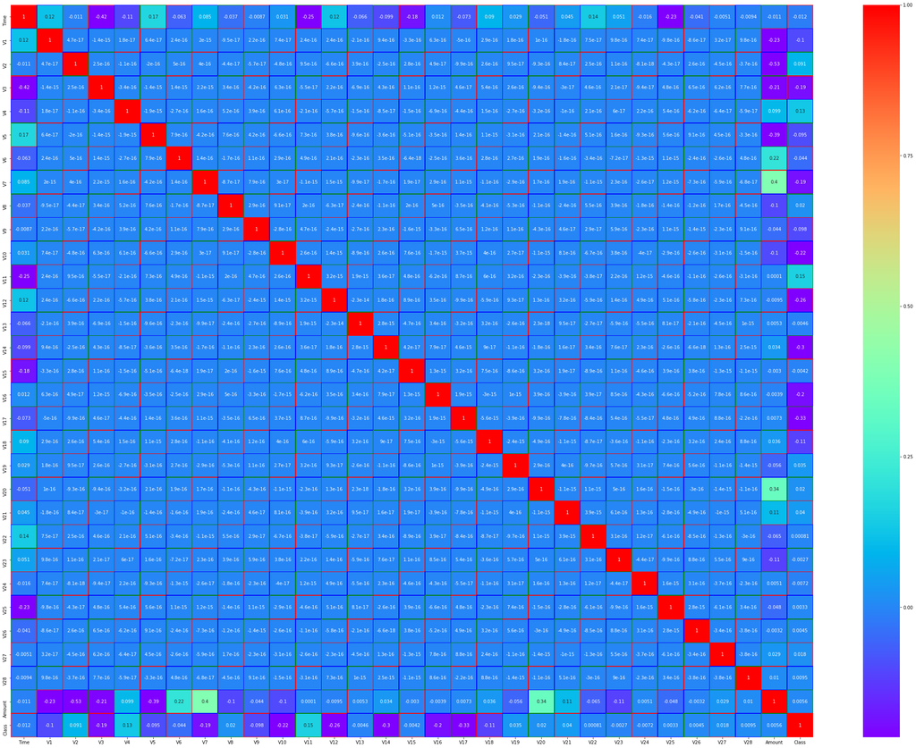

```python
dt_corr=dt_train.corr()
plt.figure(figsize=(40,30))
sns.heatmap(dt_corr,linewidth=0.5,cmap="rainbow",annot=True,robust=True,linecolor="rbg")
plt.show()
```

```
Class    1.000000
V11      0.154876
V4       0.133447
V2       0.091289
V21      0.040413
V19      0.034783
V20      0.020090
V8       0.019875
V27      0.017580
V28      0.009536
Name: Class, dtype: float64
```

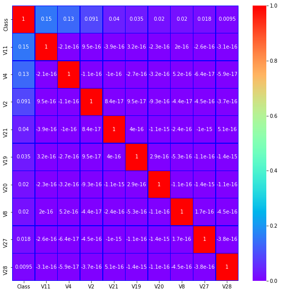

```python
dt_corr=dt_train.corr()
dt_corr1=[]
dt_corr1=dt_corr.nlargest(10, 'Class')['Class'].abs()
print(dt_corr1)

displaycorr=dt_train[['Class','V11','V4','V2','V21','V19','V20','V8','V27','V28']].corr()
plt.figure(figsize=(10,10))
sns.heatmap(displaycorr,linewidth=0.5,cmap="rainbow",annot=True,robust=True,linecolor="Blue")
plt.show()
```

1. NOw lets find the skewness of all features and if skewness is nore than 0.75, then we will convert it into logarithmic
2. its look like , there are few columns who has high skewness than our criteria
3. those feature need to converted with logarithmic so that they are in scale

```
['Time', 'V1', 'V2', 'V3', 'V4', 'V5', 'V6', 'V7', 'V8', 'V9', 'V10', 'V11', 'V12', 'V13', 'V14', 'V15', 'V16', 'V17', 'V18', 'V19', 'V20', 'V21', 'V22', 'V23', 'V24', 'V25', 'V26', 'V27', 'V28', 'Amount', 'Class']
[-0.03556743 -3.28065002 -4.62484122 -2.24014364  0.67628854 -2.42588872
  1.82657104  2.55389397 -8.52189931  0.55467685  1.18713434  0.35650398
 -2.27838894  0.06523311 -1.99516533 -0.30842136 -1.10096048 -3.84489422
 -0.2598789   0.10919118 -2.03714457  3.59297227 -0.2132565  -5.8751094
 -0.55249639 -0.4157904   0.57668958 -1.17020278 11.19203225 16.97763504
 23.99745292]
```

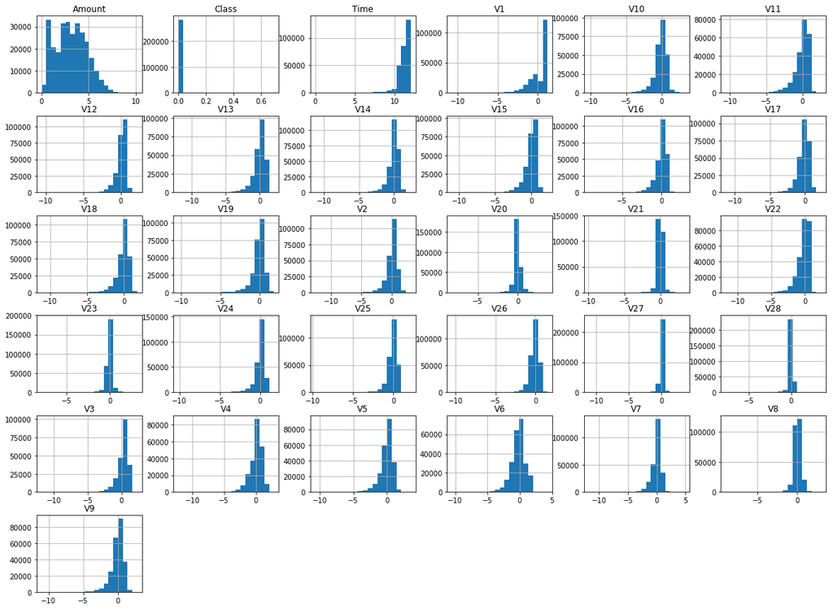

```python
col_number = dt_train.select_dtypes(include=['number']).columns.tolist()
print(col_number)
for col_transform in col_number:
    skewness = sc.stats.skew(dt_train[col_number])
print(skewness)
if skewness.all() > 0.75:
    dt_train[col_number] = np.log1p(dt_train[col_number])

dt_train.hist(bins=20, figsize=(20, 15))
plt.show()
```

Lets handle missing value with mean of that feature if any

```python
dt_train=dt_train.fillna(dt_train.mean())
```

```python
print(dt_train.shape)
```

```
(284807, 31)
```

1. Now we will split our dataset for training and testing purpose.
2. X will contain all feature except target 'Class' feature
3. Y will contain target variable 'Class'

**Imbalanced dataset**

1. if you look into our dataset, dataset is totally imballanced , as ratio is 99:1
2. if you train our model with this dataset then it is highly overfitting
3. now we can handle this with one of the technique of handling imbalance dataset
4. we will use SMOTE() to handle imbalanced dataset oversampling

```python
#dt_copy=dt_train.copy()
X=dt_train.drop(['Class'],axis=1)
Y=dt_train['Class']

lab_enc =LabelEncoder()
Y = lab_enc.fit_transform(Y)

sm=SMOTE()
X1,Y1=sm.fit_sample(X,Y)

ad=ADASYN()
X2,Y2=ad.fit_sample(X,Y)


X_train,X_test,Y_train,Y_test=train_test_split(X1,Y1,random_state=7,test_size=0.40)
X1_train,X1_test,Y1_train,Y1_test=train_test_split(X2,Y2,random_state=7,test_size=0.40)
```

Now we dont know which algorithm will best fit for our dataset so lets try all algorithms one by one

1. As dataset contain almost 400K rows and with current system CPU and available RAM , it will take lot of time to handle it
2. so we will dask distributed computing which will boost our execution
3. for that we will create cluster on our local
4. with parallel_backend with dask we will use all our reguler sklearn code

```python
%timeit
from dask.distributed import Client,LocalCluster
from sklearn.externals.joblib import parallel_backend
cluster=LocalCluster()
client = Client(cluster)  # Connect to a Dask Cluster

with parallel_backend('dask'):
    pipeEse=[]
    pipeEse.append(('ScaledAdaB',Pipeline([('Scaler',StandardScaler()),('AdaB',AdaBoostClassifier())])))
    pipeEse.append(('ScaledGB',Pipeline([('Scaler',StandardScaler()),('GB',GradientBoostingClassifier())])))
    pipeEse.append(('ScaledRFR',Pipeline([('Scaler',StandardScaler()),('RFR',RandomForestClassifier())])))
    pipeEse.append(('ScaledETR',Pipeline([('Scaler',StandardScaler()),('ETR',ExtraTreesClassifier())])))
    pipeEse.append(('ScaleLogR',Pipeline([('Scaler',StandardScaler()),('LogR',LogisticRegression())])))
    pipeEse.append(('ScaleSVC',Pipeline([('Scaler',StandardScaler()),('SVC',SVC())])))


    names=[]
    result=[]
    for name,model in pipeEse:
        kfolds=KFold(n_splits=10,random_state=7)
        cv_results=cross_val_score(model,X_train,Y_train,cv=kfolds,scoring='accuracy')
        result.append(cv_results)
        names.append(name)
        print(name, cv_results.mean() ,cv_results.std())
```

[output not shown]

```python
#Final model Initialization
%timeit
scaleF=StandardScaler().fit(X_train)
trnsF=scaleF.transform(X_train)
modelB=GradientBoostingClassifier(random_state=7,n_estimators=400)
modelB.fit(trnsF,Y_train)
trnsF2=scaleF.transform(X_test)
decision=modelB.predict(trnsF2)
finalScore=accuracy_score(decision,Y_test)
finalScore1=confusion_matrix(decision,Y_test)
finalScore2=classification_report(decision,Y_test)
```

```python
print(finalScore)
print(finalScore1)
print(finalScore2)
```

```
0.9980567328491287
[[113424     95]
 [   347 113586]]
              precision    recall  f1-score   support

           0       1.00      1.00      1.00    113519
           1       1.00      1.00      1.00    113933

   micro avg       1.00      1.00      1.00    227452
   macro avg       1.00      1.00      1.00    227452
weighted avg       1.00      1.00      1.00    227452
```

From the above results ,its look like we got good accuracy score, and confusion matrix results look good.

```python
finalScore3=roc_auc_score(Y_test,decision)
finalScore3
```

```
0.9980571709378605
```

```python
finalScore5=roc_curve(Y_test,decision)
finalScore5
```

```
(array([0.        , 0.00304999, 1.        ]),
 array([0.        , 0.99916433, 1.        ]),
 array([2, 1, 0], dtype=int64))
```

```python
false_positive_rate, true_positive_rate, thresholds = roc_curve(Y_test,decision)

finalScore4=auc(false_positive_rate, true_positive_rate)
finalScore4
```

```
0.9980571709378605
```